# Лабораторная работа №3

Реутов Александр

2022-12-29

#### Задача 1

### 1. Постановка задачи

Дан файл с данными ExpImp.RData. Необходимо отобразить суммарные значения экспорта и импорта по субъектам федерации, находящимся в Центральном федеральном округе, в виде столбчатой диаграммы. Экспорт и импорт обозначить разными цветами и сделать второй график, наложив столбцы экспорта и импорта один на другой и подписав значения разниц между экспортом и импортом.

### 2. Работа с данными

Загрузим данные и запишем в переменную data. Также подключим необходимые библиотеки

```r
library(stringr)
library(dplyr)
```

```r
library(tidyr)
library(ggplot2)
load("C:/Users/reuto/Documents/R_lab3/ExpImp.RData")
data <- ExpImp
```

Некоторые колонки содержат строковый тип, но определяют числа, поэтому преобразуем все строковые записи в double и уберем Nan, получающийся от прочерков

```r
for (i in 2:length(names(data))) {
  data[[i]] <- as.double(data[[i]])
}
data <- drop_na(data)
```

Найдем индексы тех строк, название региона которых содержит “федеральный округ”. Явно удалим из таблицы те, записи, что идут после второго индекса, так как соответствуют уже не Центральному федеральному округу.

```r
district <- grep('федеральный округ', data$Регион)
data <- data[-c(17:74), ]
```

Оставим только те записи, что соответствуют субъектам.

```r
filt <- !str_detect(data$Регион, 'Российская Федерация|федеральный округ')
data <- filter(data, filt)
```

Выберем отдельно записи с экспортом и импортом, посчитаем сумму значений каждого и разницу между суммой экспорта и суммой импорта

```r
export <- select_at(data, vars(matches("Экспорт")))
import <- select_at(data, vars(matches("Импорт")))
export$Total_Sum <- rowSums(export, na.rm = TRUE)
import$Total_Sum <- rowSums(import, na.rm = TRUE)
dif <- export$Total_Sum - import$Total_Sum
```

Заготовка для второго подзадания:

```r
data2 <- data
```

```r
data$СумЭкспорт <- export$Total_Sum
data$СумИмпорт <- import$Total_Sum
data$Разница <- dif
data <- data[,c("Регион", "СумЭкспорт", "СумИмпорт","Разница")]
```

Приведем таблицу к удобному виду с помощью pivot_longer. Новая колонка будет содержать экспорт и импорт вместе и их значения в млн. $(вторая колонка). Просуммируем значения по каждому субъекту.

```r
data <- data%>%pivot_longer(names_to = "Экспорт+Импорт", values_to = "млн. $", СумЭкспорт:СумИмпорт)
region_sum <- data %>% group_by(Регион, `Экспорт+Импорт`)%>% summarise(total_sum = sum(`млн. $`), total_dif = `Разница`, .groups = 'drop')
```

Построим график, отражающий по отдельности цветами экспорт и импорт, а также численно их разницу

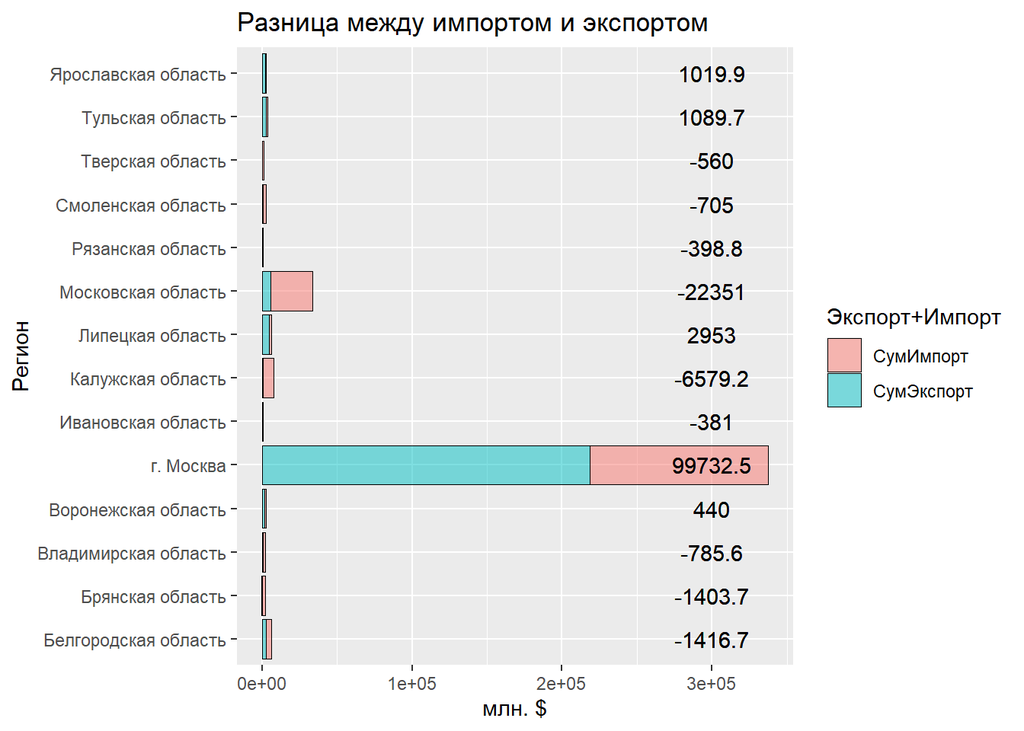

```r
region_sum |>
    ggplot(mapping = aes(x = Регион, y = total_sum, fill = `Экспорт+Импорт`)) +
    geom_col(color = 'black', size = 0.3, position = 'stack',alpha=0.5) +
    ggtitle("Разница между импортом и экспортом")+
    ylab('млн. $') + coord_flip() +
    geom_text(aes(y=300000, label = `total_dif`))
```

```r
data <- data2
data$ОбщСум <- export$Total_Sum + import$Total_Sum
data <- data[,c("Регион", "ОбщСум")]
```

График для общей суммы экспорта и импорта

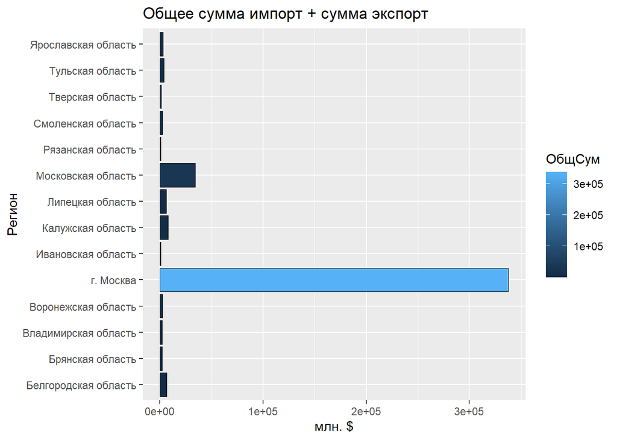

```r
data |>
    ggplot(mapping = aes(x = Регион, y = `ОбщСум`, fill = `ОбщСум`)) +
    geom_col(color = 'black', size = 0.3, alpha=1) +
    ggtitle("Общее сумма импорт + сумма экспорт") +
    ylab('млн. $') + coord_flip()
```

#### Задача 2

### 1. Постановка задачи

Даны два файла с данными data2.csv, data1.txt, в которых содержатся значения фенотипических признаков сортов сои. Количественные признаки: Height, Protein, Oil. Качественные признаки: GermBMatur, GrowthType, Polegaemost, MaturType. Идентификаторы сортов: V_1, V_2, …. Необходимо объединить data.frames по идентификаторам сортов. Исключить те сорта, для которых есть пропущенные значения. Для всех количественных величин нарисовать гистограммы и плотности распределения (на одном рисунке). Выбрать одну количественную и две качественные переменные . Нарисовать столбчатую диаграмму, в которой значениям на оси x соответствуют значениям одной качественной переменной и значения другой качественной переменной показаны при помощи цвета. Для количественной переменной нарисовать график плотности и гистограмму(в 2 слоя) на одном графике, и boxplot - на другом.

### 2. Работа с данными

Подключим необходимые библиотеки

```r
library(stringr)
library(dplyr)
library(tidyr)
library(readr)
library(ggplot2)
library (data.table)
```

Загрузим data1.txt и приведем к виду таблицы data2.csv

```r
data1 <- read.table("C:/Users/reuto/Documents/R_lab3/data1.txt")
new_names = data1$V1
df_t <- transpose(data1)
names(df_t) <- new_names
df_t <- df_t[-1, ]
```

Загружаем вторую таблицу и сливаем вместе две таблицы

```r
data2 <- read.csv("C:/Users/reuto/Documents/R_lab3/data2.csv")
colnames(data2)[1] <- "Sample"
data <- merge(df_t, data2, all.x = TRUE, all.y=TRUE)
```

Удалим те записи, что содержат NAs и выделим две подтаблицы, содержащие количественные и качественные признаки

```r
data <- data[ , colSums(is.na(data))== 0 ]
colich <- data[c(3,5,7),]
cach <- data[c(2, 4),]
```

Отобразим графики, содержащие гистограмму и плотность распределния для каждого из количественных признаков Для признака Height:

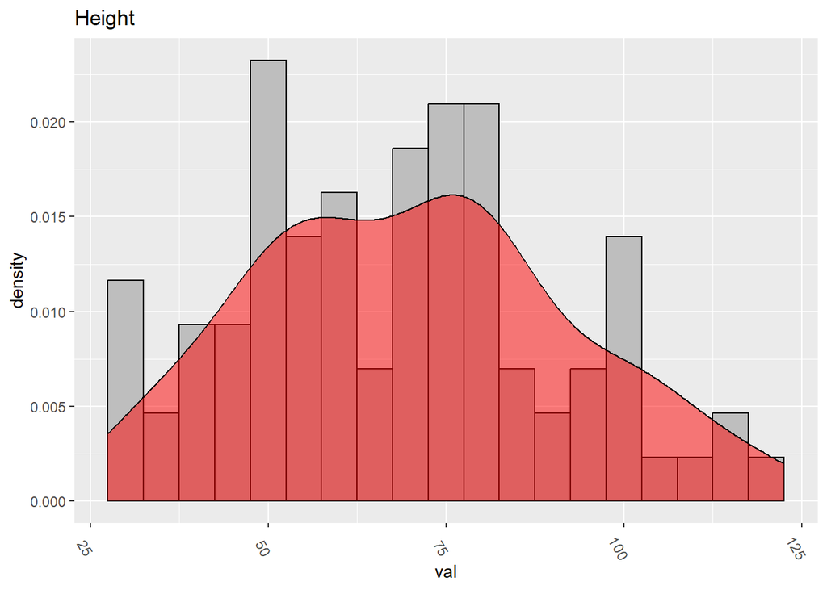

```r
colich_1 <- colich[1,]
colich_1 <- colich_1 %>% pivot_longer(names_to = "V", values_to = "val", V_0:V_100)
colich_1$val <- as.double(colich_1$val)
ggplot(colich_1, mapping = aes(x=val)) + geom_histogram(aes(y=..density..),binwidth=5, colour="black", fill="grey")+
  theme(axis.text.x = element_text(angle = 300)) + geom_density(alpha=.5, fill="red") + ggtitle("Height")
```

Для признака Oil:

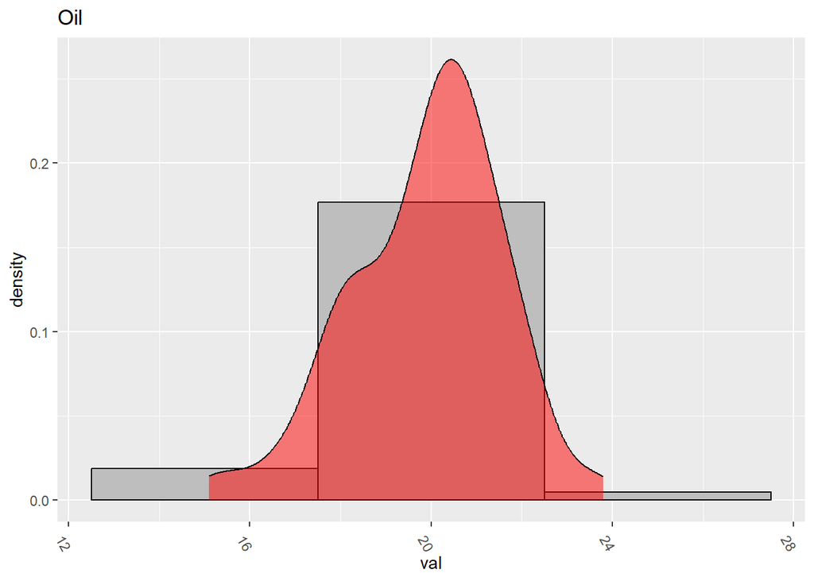

```r
colich_2 <- colich[2,]
colich_2 <- colich_2 %>% pivot_longer(names_to = "V", values_to = "val", V_0:V_100)
colich_2$val <- as.double(colich_2$val)
ggplot(colich_2, mapping = aes(x=val)) + geom_histogram(aes(y=..density..),binwidth=5, colour="black", fill="grey")+
  theme(axis.text.x = element_text(angle = 300)) + geom_density(alpha=.5, fill="red") + ggtitle("Oil")
```

Для признака Protein:

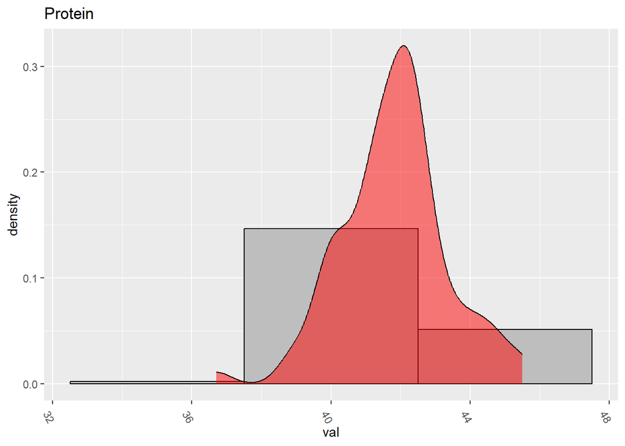

```r
colich_3 <- colich[3,]
colich_3 <- colich_3 %>% pivot_longer(names_to = "V", values_to = "val", V_0:V_100)
colich_3$val <- as.double(colich_3$val)
ggplot(colich_3, mapping = aes(x=val)) + geom_histogram(aes(y=..density..),binwidth=5, colour="black", fill="grey")+
  theme(axis.text.x = element_text(angle = 300)) + geom_density(alpha=.5, fill="red") + ggtitle("Protein")
```

Пусть количественный будет Oil, качественные: GrowthType, MaturType Выведем столбчатую диаграмму для качественных признаков

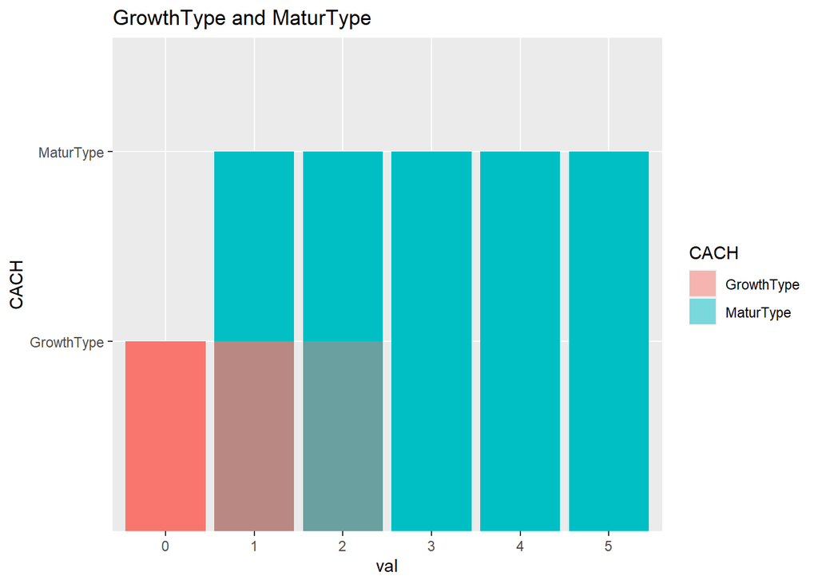

```r
new_names = cach$Sample
df <- transpose(cach)
names(df) <- new_names
row.names(df)<-colnames(cach)
df <- df[-1,]

df <- df%>% pivot_longer(names_to = "CACH", values_to = "val", GrowthType:MaturType)
ggplot(df, mapping = aes(x = val,y = CACH, fill = CACH)) +
  geom_col(position = 'identity',alpha=0.5) +
  ggtitle("GrowthType and MaturType")
```

Гистограмма и график плотности для количественного признака Oil:

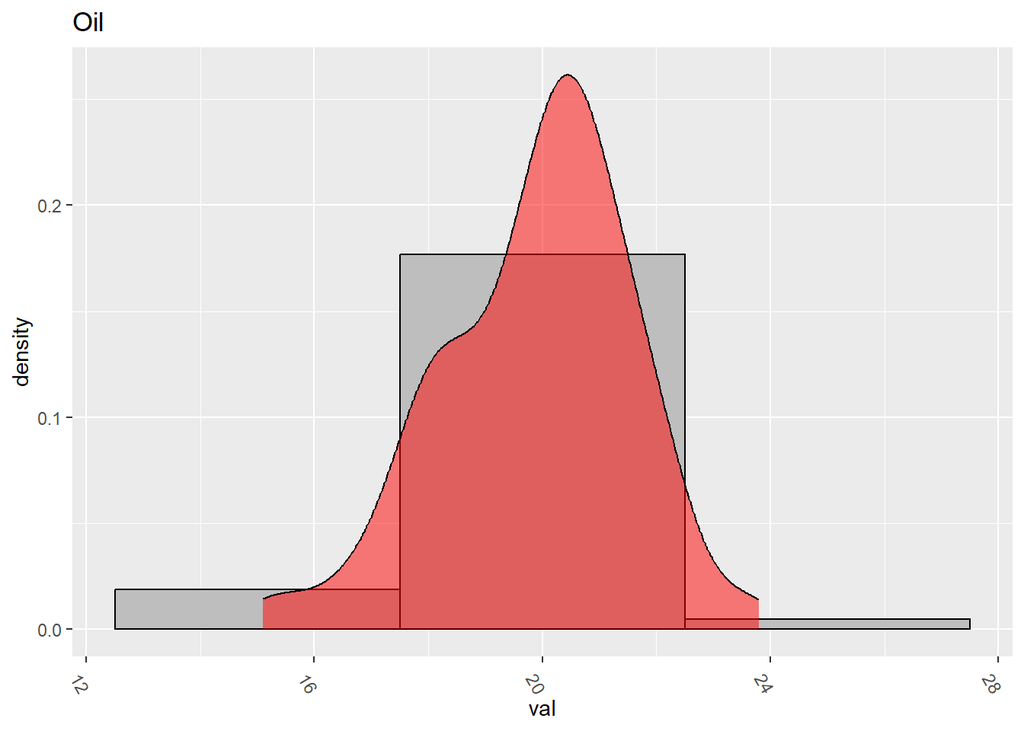

```r
ggplot(colich_2, mapping = aes(x=val)) + geom_histogram(aes(y=..density..),binwidth=5, colour="black", fill="grey")+
  theme(axis.text.x = element_text(angle = 300)) + geom_density(alpha=.5, fill="red") + ggtitle("Oil")
```

boxplot для количественного признака Oil:

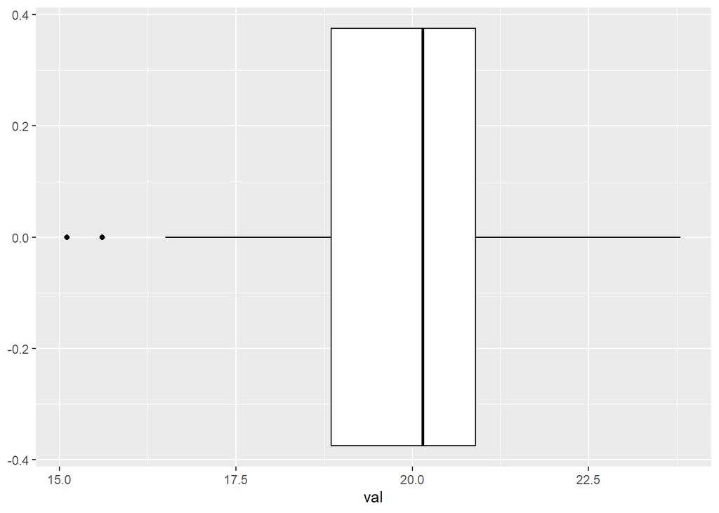

```r
ggplot(colich_2, aes(x=val)) + geom_boxplot(colour="black")
```